# Tugas Praktikum MPDW Pertemuan 2

# IMPOR DATA

```r
library(readxl)
data <- read_xlsx("/Users/mrkahar/Downloads/JKSE_Close_Weekly.xlsx")

data1 <- data[776:1033, ]
data1
```

```
## # A tibble: 258 × 2
##    Date                Close
##    <dttm>              <dbl>
##  1 2020-08-24 00:00:00 5347.
##  2 2020-08-31 00:00:00 5240.
##  3 2020-09-07 00:00:00 5017.
##  4 2020-09-14 00:00:00 5059.
##  5 2020-09-21 00:00:00 4946.
##  6 2020-09-28 00:00:00 4927.
##  7 2020-10-05 00:00:00 5054.
##  8 2020-10-12 00:00:00 5103.
##  9 2020-10-19 00:00:00 5112.
## 10 2020-10-26 00:00:00 5128.
## # ℹ 248 more rows
```

# EKSPLORASI DATA

```r
str(data1)
```

```
## tibble [258 × 2] (S3: tbl_df/tbl/data.frame)
##  $ Date : POSIXct[1:258], format: "2020-08-24" "2020-08-31" ...
##  $ Close: num [1:258] 5347 5240 5017 5059 4946 ...
```

```r
dim(data1)
```

```
## [1] 258   2
```

```r
data1.ts <- ts(data1$Close)
summary(data1.ts)
```

```
##    Min. 1st Qu.  Median    Mean 3rd Qu.    Max.
##    4927    6521    6872    6750    7137    7898
```

## Plot Deret Waktu

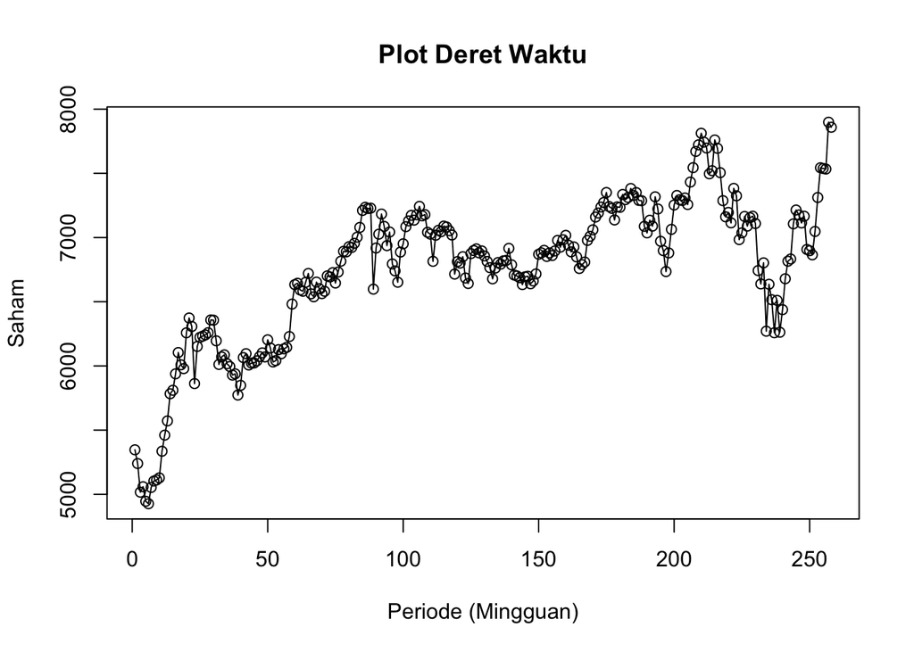

```r
ts.plot(data1.ts, xlab="Periode (Mingguan)", ylab="Saham",
        main = "Plot Deret Waktu")
points(data1.ts)
```

**Interpretasi:**

1. Terlihat tren naik yang signifikan sepanjang periode pengamatan dengan beberapa fluktuasi yang menunjukkan saham mengalami pertumbuhan secara keseluruhan meskipun ada hambatan seperti risiko pasar.
2. Data non-stasioner, artinya nilai rata-rata dan ragam tidak konstan.
3. Tidak terindikasi pola musiman yang kuat.

# Pembagian Data Latih dan Uji

```r
library(forecast)
n <- nrow(data1)
n_train <- floor(0.8 * n)

training <- data1[1:n_train, ]
testing  <- data1[(n_train+1):n, ]

train.ts <- ts(training$Close)
test.ts  <- ts(testing$Close)

# Data Latih
train.ts
```

```
## Time Series:
## Start = 1
## End = 206
## Frequency = 1
##   [1] 5346.659 5239.851 5016.712 5059.223 4945.791 4926.734 5053.663 5103.414
##   [9] 5112.188 5128.225 5335.529 5461.058 5571.656 5783.335 5810.483 5938.329
##  [17] 6104.324 6008.709 5979.073 6257.835 6373.412 6307.127 5862.352 6151.729
##  [25] 6222.521 6231.932 6241.796 6258.749 6358.209 6356.160 6195.562 6011.456
##  [33] 6070.209 6086.258 6016.864 5995.616 5928.309 5938.351 5773.120 5848.616
##  [41] 6065.166 6095.497 6007.120 6022.399 6023.008 6039.844 6072.510 6101.690
##  [49] 6070.039 6203.431 6139.492 6030.772 6041.366 6126.921 6094.873 6133.246
##  [57] 6144.815 6228.845 6481.769 6633.338 6643.738 6591.346 6581.785 6651.054
##  [65] 6720.263 6561.553 6538.506 6652.922 6601.932 6562.900 6581.482 6701.316
##  [73] 6693.401 6726.373 6645.511 6731.391 6815.607 6892.818 6888.171 6928.328
##  [81] 6922.602 6954.965 7002.532 7078.760 7210.835 7235.532 7225.606 7228.914
##  [89] 6597.993 6918.144 7026.256 7182.961 7086.648 6936.967 7042.937 6794.328
##  [97] 6740.219 6651.905 6886.962 6951.123 7084.655 7129.277 7172.434 7135.248
## [105] 7177.179 7242.656 7168.870 7178.583 7040.798 7026.783 6814.530 7017.771
## [113] 7056.040 7045.527 7089.206 7082.181 7053.150 7019.639 6715.118 6812.193
## [121] 6800.673 6850.619 6684.558 6641.830 6874.931 6898.981 6911.732 6880.329
## [129] 6895.714 6856.576 6813.636 6765.302 6678.237 6762.254 6805.277 6792.765
## [137] 6818.574 6821.807 6915.716 6787.631 6707.763 6700.561 6687.001 6633.261
## [145] 6694.024 6698.547 6639.733 6661.879 6716.459 6869.572 6880.802 6900.230
## [153] 6852.842 6879.979 6859.912 6895.443 6977.654 6924.780 6982.791 7016.844
## [161] 6939.892 6888.518 6926.780 6849.168 6758.793 6788.850 6809.263 6977.668
## [169] 7009.631 7059.906 7159.598 7190.988 7237.519 7272.797 7350.619 7241.138
## [177] 7227.402 7137.088 7238.785 7235.152 7335.545 7295.095 7311.907 7381.907
## [185] 7328.054 7350.152 7288.813 7286.882 7087.317 7036.075 7134.724 7088.795
## [193] 7317.238 7222.382 6970.736 6897.950 6734.832 6879.978 7063.577 7253.372
## [201] 7327.580 7294.495 7288.167 7308.123 7256.996 7432.090
```

```r
# Data Uji
test.ts
```

```
## Time Series:
## Start = 1
## End = 52
## Frequency = 1
##  [1] 7544.298 7670.733 7721.846 7812.131 7743.004 7696.916 7496.091 7520.602
##  [9] 7760.060 7694.660 7505.257 7287.191 7161.258 7195.565 7114.266 7382.785
## [17] 7324.789 6983.865 7036.571 7164.429 7088.866 7154.658 7166.056 7109.196
## [25] 6742.576 6638.459 6803.001 6270.597 6636.000 6515.631 6258.179 6510.620
## [33] 6262.226 6438.269 6678.915 6815.730 6832.803 7106.526 7214.163 7175.819
## [41] 7113.425 7166.065 6907.138 6897.400 6865.192 7047.438 7311.915 7543.503
## [49] 7537.768 7533.385 7898.375 7858.851
```

## Plot Data Latih

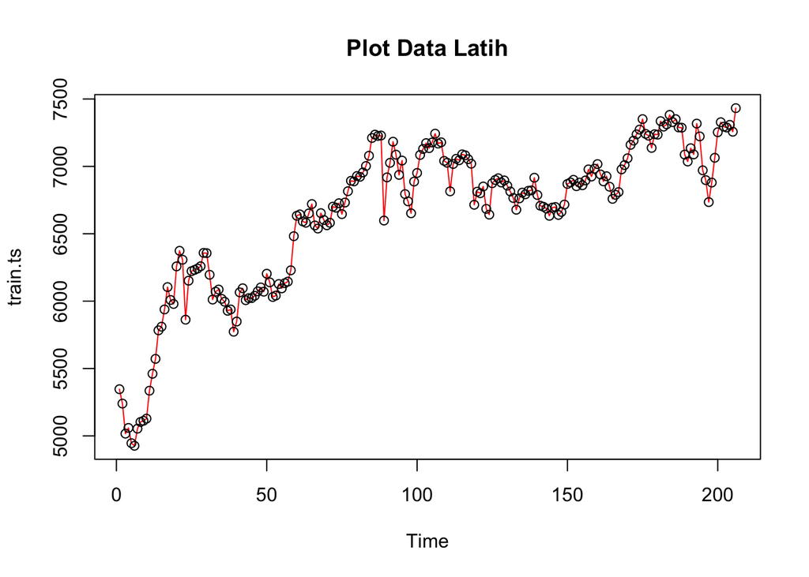

```r
plot(train.ts, col="red",main="Plot Data Latih")
points(train.ts)
```

## Plot Data Uji

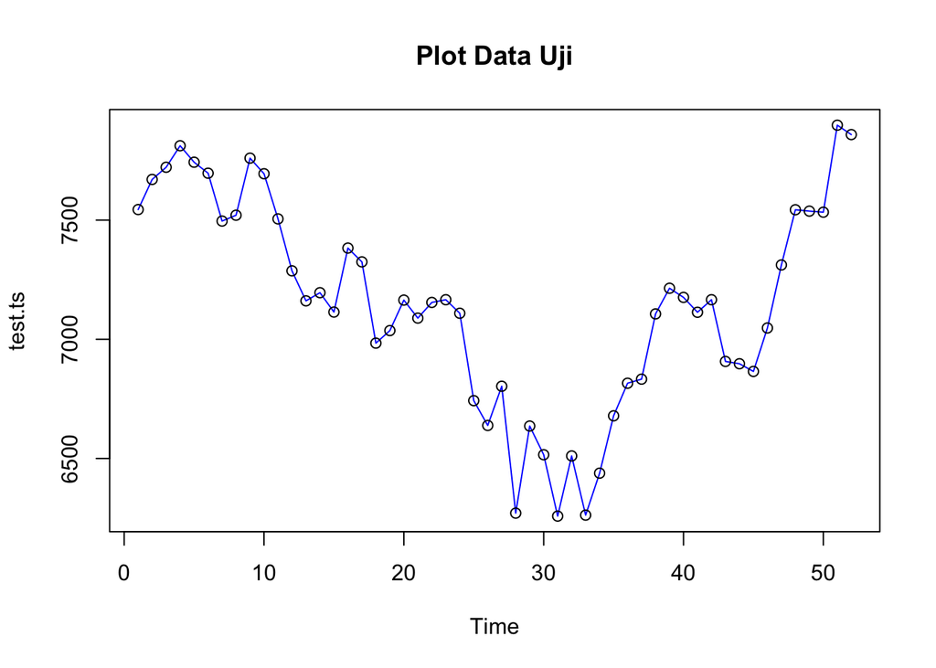

```r
plot(test.ts, col="blue",main="Plot Data Uji")
points(test.ts)
```

## Plot Gabungan Data Latih & Uji

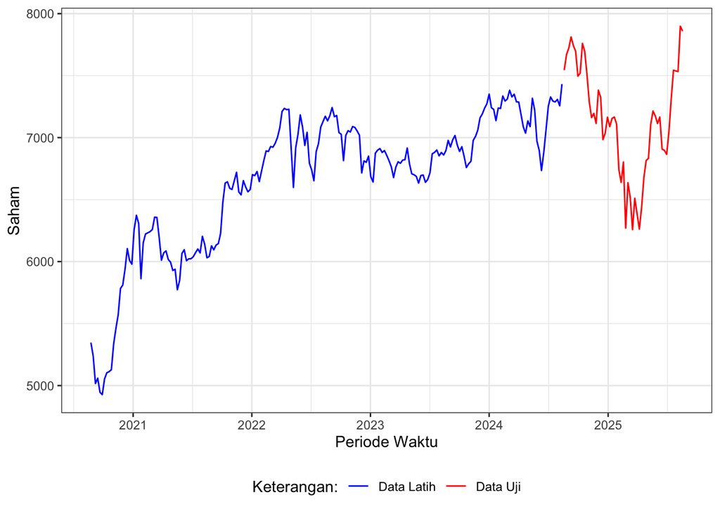

```r
library(ggplot2)
ggplot() +
  geom_line(data = training, aes(x = Date, y = Close, col = "Data Latih")) +
geom_line(data = testing, aes(x = Date, y = Close, col = "Data Uji")) +
  labs(x = "Periode Waktu", y = "Saham", color = "Legend") +
  scale_colour_manual(name="Keterangan:", breaks = c("Data Latih", "Data Uji"),
                      values = c("blue", "red")) +
  theme_bw() + theme(legend.position = "bottom",
                     plot.caption = element_text(hjust=0.5, size=12))
```

**Kesimpulan:** Berdasarkan hasil eksplorasi, ditemukan bahwa data memiliki tren naik pada jangka panjang dan fluktuasi pada jangka pendek namun tidak memiliki pola musiman yang jelas. Oleh sebab itu, metode pemulusan yang lebih tepat digunakan adalah **Double Exponential Smoothing.**

# DOUBLE EXPONENTIAL SMOOTHING (DES)

### Lambda = 0,2 & Gamma = 0,2

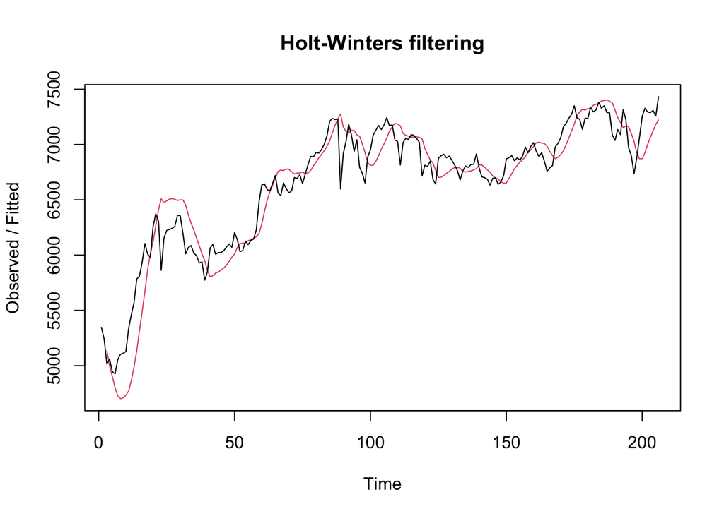

```r
horizon <- length(testing$Close)

des.1<- HoltWinters(train.ts, gamma = FALSE, beta = 0.2, alpha = 0.2)
plot(des.1)
```

```r
# Ramalan
ramalandes1<- forecast(des.1, h=horizon)
ramalandes1
```

```
##     Point Forecast    Lo 80     Hi 80    Lo 95     Hi 95
## 207       7297.075 7037.628  7556.523 6900.284  7693.866
## 208       7330.287 7063.472  7597.102 6922.228  7738.345
## 209       7363.498 7086.970  7640.026 6940.585  7786.411
## 210       7396.709 7107.987  7685.432 6955.147  7838.272
## 211       7429.921 7126.467  7733.375 6965.828  7894.014
## 212       7463.132 7142.423  7783.841 6972.650  7953.614
## 213       7496.343 7155.923  7836.764 6975.715  8016.972
## 214       7529.555 7167.070  7892.039 6975.182  8083.927
## 215       7562.766 7175.989  7949.543 6971.241  8154.291
## 216       7595.977 7182.812  8009.143 6964.095  8227.860
## 217       7629.189 7187.670  8070.707 6953.944  8304.433
## 218       7662.400 7190.690  8134.110 6940.982  8383.818
## 219       7695.611 7191.989  8199.234 6925.387  8465.836
## 220       7728.823 7191.672  8265.973 6907.322  8550.324
```

[output cut: 38 more lines]

### Lambda = 0,15 & Gamma = 0,05

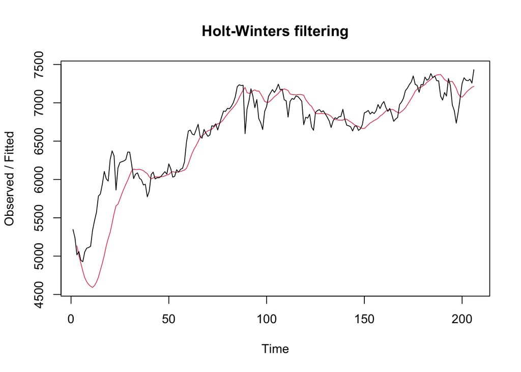

```r
des.2<- HoltWinters(train.ts, gamma = FALSE, beta = 0.05, alpha = 0.15)
plot(des.2)
```

```r
# Ramalan
ramalandes2<- forecast(des.2, h=horizon)
ramalandes2
```

```
##     Point Forecast    Lo 80    Hi 80    Lo 95    Hi 95
## 207       7252.634 6900.142 7605.125 6713.545 7791.723
## 208       7257.816 6900.980 7614.653 6712.082 7803.551
## 209       7262.998 6901.453 7624.544 6710.062 7815.935
## 210       7268.181 6901.558 7634.804 6707.479 7828.882
## 211       7273.363 6901.290 7645.436 6704.327 7842.399
## 212       7278.545 6900.648 7656.442 6700.601 7856.489
## 213       7283.727 6899.630 7667.825 6696.301 7871.154
## 214       7288.910 6898.236 7679.583 6691.426 7886.393
## 215       7294.092 6896.467 7691.717 6685.978 7902.206
## 216       7299.274 6894.326 7704.222 6679.959 7918.589
## 217       7304.456 6891.815 7717.098 6673.375 7935.538
## 218       7309.639 6888.937 7730.340 6666.231 7953.046
## 219       7314.821 6885.698 7743.944 6658.534 7971.108
## 220       7320.003 6882.102 7757.905 6650.291 7989.716
```

[output cut: 38 more lines]

### Lambda & Gamma Optimum

```r
des.opt<- HoltWinters(train.ts, gamma = FALSE)
des.opt
```

```
## Holt-Winters exponential smoothing with trend and without seasonal component.
##
## Call:
## HoltWinters(x = train.ts, gamma = FALSE)
##
## Smoothing parameters:
##  alpha: 1
##  beta : 0.07049081
##  gamma: FALSE
##
## Coefficients:
##         [,1]
## a 7432.08984
## b   19.12056
```

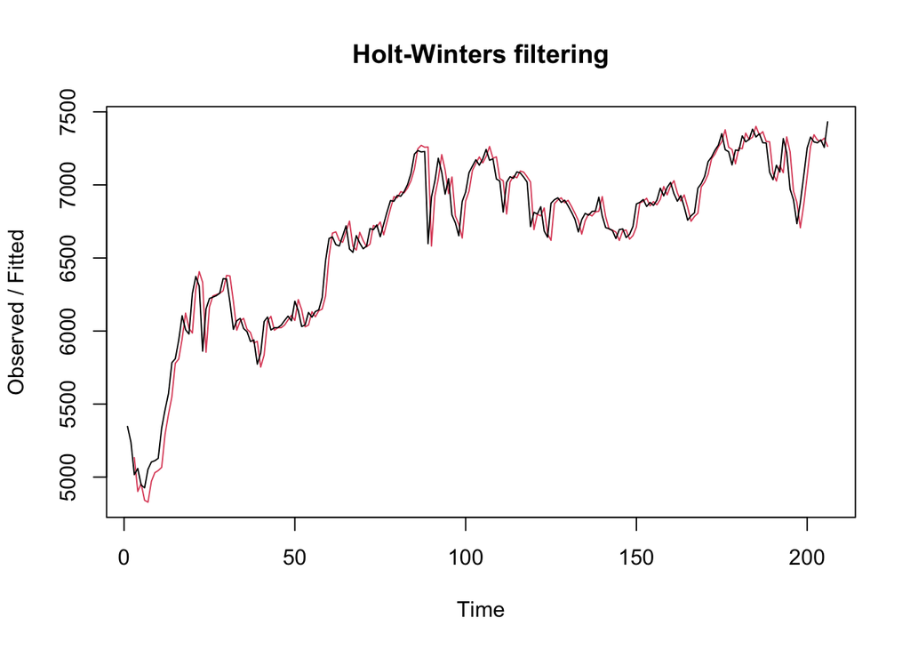

```r
plot(des.opt)
```

```r
# Ramalan
ramalandesopt<- forecast(des.opt, h=horizon)
ramalandesopt
```

```
##     Point Forecast    Lo 80     Hi 80    Lo 95     Hi 95
## 207       7451.210 7297.087  7605.334 7215.499  7686.922
## 208       7470.331 7244.555  7696.107 7125.036  7815.626
## 209       7489.452 7203.272  7775.631 7051.778  7927.125
## 210       7508.572 7166.868  7850.276 6985.981  8031.163
## 211       7527.693 7132.978  7922.407 6924.029  8131.357
## 212       7546.813 7100.440  7993.186 6864.145  8229.482
## 213       7565.934 7068.596  8063.272 6805.321  8326.547
## 214       7585.054 7037.035  8133.073 6746.931  8423.177
## 215       7604.175 7005.490  8202.860 6688.565  8519.785
## 216       7623.295 6973.774  8272.817 6629.938  8616.653
## 217       7642.416 6941.756  8343.076 6570.849  8713.983
## 218       7661.537 6909.341  8413.732 6511.153  8811.920
## 219       7680.657 6876.459  8484.856 6450.742  8910.573
## 220       7699.778 6843.056  8556.499 6389.535  9010.020
```

[output cut: 38 more lines]

# Akurasi Data Latih

### Lambda = 0,2 & Gamma = 0,2

```r
ssedes.train1<-des.1$SSE
msedes.train1<-ssedes.train1/length(train.ts)
sisaandes1<-ramalandes1$residuals
head(sisaandes1)
```

```
## Time Series:
## Start = 1
## End = 6
## Frequency = 1
## [1]         NA         NA -116.33105   60.90773   44.31910  123.65042
```

```r
mapedes.train1 <- sum(abs(sisaandes1[3:length(train.ts)]/train.ts[3:length(train.ts)])
                      *100)/length(train.ts)

akurasides.1 <- matrix(c(ssedes.train1,msedes.train1,mapedes.train1))
row.names(akurasides.1)<- c("SSE", "MSE", "MAPE")
colnames(akurasides.1) <- c("Akurasi lamda=0.2 dan gamma=0.2")
akurasides.1
```

```
##      Akurasi lamda=0.2 dan gamma=0.2
## SSE                     8.380067e+06
## MSE                     4.067994e+04
## MAPE                    2.360594e+00
```

### Lambda = 0,15 & Gamma = 0,05

```r
ssedes.train2<-des.2$SSE
msedes.train2<-ssedes.train2/length(train.ts)
sisaandes2<-ramalandes2$residuals
head(sisaandes2)
```

```
## Time Series:
## Start = 1
## End = 6
## Frequency = 1
## [1]         NA         NA -116.33105   51.31042   37.47749  119.81342
```

```r
mapedes.train2 <- sum(abs(sisaandes2[3:length(train.ts)]/train.ts[3:length(train.ts)])
                      *100)/length(train.ts)

akurasides.2 <- matrix(c(ssedes.train2,msedes.train2,mapedes.train2))
row.names(akurasides.2)<- c("SSE", "MSE", "MAPE")
colnames(akurasides.2) <- c("Akurasi lamda=0.15 dan gamma=0.05")
akurasides.2
```

```
##      Akurasi lamda=0.15 dan gamma=0.05
## SSE                       1.645049e+07
## MSE                       7.985675e+04
## MAPE                      2.789132e+00
```

### Lambda & Gamma Optimum

```r
ssedes.trainopt<-des.opt$SSE
msedes.trainopt<-ssedes.trainopt/length(train.ts)
sisaandesopt<-ramalandesopt$residuals
head(sisaandesopt)
```

```
## Time Series:
## Start = 1
## End = 6
## Frequency = 1
## [1]          NA          NA -116.331055  157.519607   -9.527438   85.519159
```

```r
mapedes.trainopt <- sum(abs(sisaandesopt[3:length(train.ts)]/train.ts[3:length(train.ts)])
                      *100)/length(train.ts)

akurasides.opt <- matrix(c(ssedes.trainopt,msedes.trainopt,mapedes.trainopt))
row.names(akurasides.opt)<- c("SSE", "MSE", "MAPE")
colnames(akurasides.opt) <- c("Akurasi lambda dan gamma optimum")
akurasides.opt
```

```
##      Akurasi lambda dan gamma optimum
## SSE                      2.951673e+06
## MSE                      1.432851e+04
## MAPE                     1.279072e+00
```

### Perbadingan Akurasi Data Latih Berdasarkan Nilai Lambda dan Gamma

```r
akurasitraindes <-
  matrix(c(ssedes.train1,msedes.train1,mapedes.train1,ssedes.train2,msedes.train2, mapedes.train2,ssedes.trainopt,msedes.trainopt,mapedes.trainopt),
         nrow=3,ncol=3)
row.names(akurasitraindes)<- c("SSE", "MSE", "MAPE")
colnames(akurasitraindes) <- c("des ske1","des ske2","des opt")
akurasitraindes
```

```
##          des ske1     des ske2      des opt
## SSE  8.380067e+06 1.645049e+07 2.951673e+06
## MSE  4.067994e+04 7.985675e+04 1.432851e+04
## MAPE 2.360594e+00 2.789132e+00 1.279072e+00
```

**Kesimpulan :**

1. Pada semua skema, diperoleh nilai MAPE sekitar 2%, nilai ini dapat dikategorikan sebagi nilai akurasi yang sangat baik.
2. Model dengan lambda dan gamma optimum memberikan hasil paling akurat untuk data latih, terlihat dari nilai MSE dan MAPE yang lebih kecil.

# Akurasi Data Uji

### Lambda = 0,2 & Gamma = 0,2

```r
selisihdes1<-ramalandes1$mean-testing$Close
selisihdes1
```

```
## Time Series:
## Start = 207
## End = 258
## Frequency = 1
##  [1] -247.2225172 -340.4462307 -358.3481668 -415.4214897 -313.0831915
##  [6] -233.7839557    0.2525847    8.9526993 -197.2939634  -98.6827159
## [11]  123.9319495  375.2092125  534.3536631  533.2578793  647.7680525
## [16]  412.4603547  503.6677935  877.8029668  858.3087455  763.6616921
## [21]  872.4360255  839.8553784  861.6687743  951.7404710 1351.5714450
## [26] 1488.8999776 1357.5693305 1923.1844842 1590.9929973 1744.5734830
## [31] 2035.2364883 1816.0069154 2097.6123035 1954.7806798 1747.3460289
## [36] 1643.7424326 1659.8805355 1419.3692243 1344.9433624 1416.4989458
## [41] 1512.1043339 1492.6755422 1784.8136452 1827.7632715 1893.1826244
## [46] 1744.1478758 1512.8821701 1314.5056246 1353.4518330 1391.0464789
## [51] 1059.2675896 1132.0028605
```

```r
SSEtestingdes1<-sum(selisihdes1^2)
MSEtestingdes1<-SSEtestingdes1/length(testing$Close)
MAPEtestingdes1<-sum(abs(selisihdes1/testing$Close)*100)/length(testing$Close)

akurasides.3 <- matrix(c(SSEtestingdes1,MSEtestingdes1,MAPEtestingdes1))
row.names(akurasides.3)<- c("SSE", "MSE", "MAPE")
colnames(akurasides.3) <- c("Akurasi lamda=0.2 dan gamma=0.2")
akurasides.3
```

```
##      Akurasi lamda=0.2 dan gamma=0.2
## SSE                     8.046961e+07
## MSE                     1.547493e+06
## MAPE                    1.551883e+01
```

### Lambda = 0,15 & Gamma = 0,05

```r
selisihdes2<-ramalandes2$mean-testing$Close
selisihdes2
```

```
## Time Series:
## Start = 207
## End = 258
## Frequency = 1
##  [1] -291.66389 -412.91670 -458.84774 -543.95016 -469.64096 -418.37083
##  [7] -212.36339 -231.69237 -465.96814 -395.38599 -200.80042   22.44774
## [13]  153.56309  124.43820  210.91928  -52.41752   10.76082  356.86689
## [19]  309.34357  186.66741  267.41265  206.80290  200.58719  262.62979
## [25]  634.43166  743.73109  584.37135 1121.95740  761.73681  887.28820
## [31] 1149.92210  902.66343 1156.23972  985.37899  749.91524  618.28254
## [37]  606.39155  337.85113  235.39617  278.92265  346.49894  299.04105
## [43]  563.15005  578.07058  615.46083  438.39698  179.10217  -47.30347
## [49]  -36.38636  -26.82082 -386.62881 -341.92264
```

```r
SSEtestingdes2<-sum(selisihdes2^2)
MSEtestingdes2<-SSEtestingdes2/length(testing$Close)
MAPEtestingdes2<-sum(abs(selisihdes2/testing$Close)*100)/length(testing$Close)

akurasides.4 <- matrix(c(SSEtestingdes2,MSEtestingdes2,MAPEtestingdes2))
row.names(akurasides.4)<- c("SSE", "MSE", "MAPE")
colnames(akurasides.4) <- c("Akurasi lamda=0.15 dan gamma=0.05")
akurasides.4
```

```
##      Akurasi lamda=0.15 dan gamma=0.05
## SSE                       1.390110e+07
## MSE                       2.673289e+05
## MAPE                      6.151179e+00
```

### Lambda & Gamma Optimum

```r
selisihdesopt<-ramalandesopt$mean-testing$Close
selisihdesopt
```

```
## Time Series:
## Start = 207
## End = 258
## Frequency = 1
##  [1]  -93.08745 -200.40195 -232.39467 -303.55878 -215.31127 -150.10282
##  [7]   69.84293   64.45226 -155.88519  -71.36473  137.15915  374.34562
## [13]  519.39929  504.21272  604.63210  355.23362  432.35027  792.39466
## [19]  758.80965  650.07181  744.75536  698.08392  705.80653  781.78744
## [25] 1167.52763 1290.76537 1145.34394 1696.86831 1350.58603 1490.07573
## [31] 1766.64795 1533.32759 1800.84219 1643.91978 1422.39434 1304.69996
## [37] 1306.74727 1052.14518  963.62853 1021.09332 1102.60793 1069.08835
## [43] 1347.13566 1375.99450 1427.32307 1264.19753 1018.84104  806.37371
## [49]  831.22913  854.73299  508.86331  567.50780
```

```r
SSEtestingdesopt<-sum(selisihdesopt^2)
MSEtestingdesopt<-SSEtestingdesopt/length(testing$Close)
MAPEtestingdesopt<-sum(abs(selisihdesopt/testing$Close)*100)/length(testing$Close)

akurasides.5 <- matrix(c(SSEtestingdesopt,MSEtestingdesopt,MAPEtestingdesopt))
row.names(akurasides.5)<- c("SSE", "MSE", "MAPE")
colnames(akurasides.5) <- c("Akurasi lambda dan gamma optimum")
akurasides.5
```

```
##      Akurasi lambda dan gamma optimum
## SSE                      5.002831e+07
## MSE                      9.620828e+05
## MAPE                     1.219453e+01
```

### Perbadingan Akurasi Data Uji Berdasarkan Nilai Lambda dan Gamma

```r
akurasitestingdes <-
  matrix(c(SSEtestingdes1,MSEtestingdes1,MAPEtestingdes1,SSEtestingdes2,MSEtestingdes2,
           MAPEtestingdes2,SSEtestingdesopt,MSEtestingdesopt,MAPEtestingdesopt),
         nrow=3,ncol=3)
row.names(akurasitestingdes)<- c("SSE", "MSE", "MAPE")
colnames(akurasitestingdes) <- c("des ske1","des ske2","des opt")
akurasitestingdes
```

```
##          des ske1     des ske2      des opt
## SSE  8.046961e+07 1.390110e+07 5.002831e+07
## MSE  1.547493e+06 2.673289e+05 9.620828e+05
## MAPE 1.551883e+01 6.151179e+00 1.219453e+01
```

**Kesimpulan :**

1. Model dengan lambda dan gamma 0,2 serta model dengan lambda dan gamma optimum memberikan hasil yang cukup akurat untuk data uji karena nilai MAPE antara 10%-20%.
2. Model dengan lambda 0,15 dan gamma 0,05 memberikan hasil paling akurat karena nilai MAPE < 10% sehingga lebih cocok digunakan untuk peramalan karena memberikan keseimbangan antara akurasi dan generalisasi.

Zifa Aura Rahman  
G1401231010